# Reduccion 17

8 actividades; límite 3 operarios, reducir dos semanas (Ackoff sin recursos falla)

# Enunciado

Considere el proyecto cuyo cuadro de prelaciones, duración normal y tope (semanas), operarios por actividad y coste unitario de reducción (k€/semana) se adjunta. Cada actividad necesita un número fijo de operarios durante toda su duración y la empresa dispone como máximo de 3 operarios en cada semana. Las actividades con CUR infinito no pueden acelerarse. Se quiere reducir la duración del proyecto **dos semanas** respetando el límite de operarios.

1. Determine la duración del proyecto sin límite de recursos y con el límite de operarios (algoritmo de asignación). Indique la cadena crítica con recursos: qué actividades fijan la duración y qué esperas por recurso intervienen.

2. Aplique el algoritmo de Ackoff-Sasieni ignorando los recursos para reducir dos semanas, aplique esas reducciones y replanifique con el límite de operarios. ¿Se ha conseguido reducir la duración del proyecto con recursos? ¿Por qué?

3. Reduzca ahora dos semanas teniendo en cuenta el límite: pruebe en cada paso los candidatos (cortes de la cadena crítica con recursos, actividades sueltas y parejas) y elija el más barato que de verdad acorte el proyecto replanificado. Compare el sobrecoste con el del apartado anterior.

4. Suponga que acelerar una actividad exige un operario más por cada semana recortada (modelo con recurso). ¿Cambia la solución?

5. Alternativa: contratar un operario más (límite 4) sin acelerar nada. ¿Qué duración se obtiene? ¿Compensa frente a acelerar?

Tabla 1: Cuadro de datos del enunciado

| activity | predecessor | duration | operarios | cap_duration | ucr |
| --- | --- | --- | --- | --- | --- |
| A | --- | 2 | 2 | 1 | 2.0 |
| B | --- | 5 | 1 | 2 | 4.0 |
| C | A | 1 | 1 | 1 | inf |
| D | C | 5 | 1 | 2 | 7.0 |
| E | A,B | 4 | 1 | 2 | 2.0 |
| F | B,D | 4 | 1 | 4 | inf |
| G | C,E | 8 | 3 | 5 | 9.0 |
| H | F,G | 2 | 1 | 2 | inf |

# Resolución

## Apartado 1

1. Determine la duración del proyecto sin límite de recursos y con el límite de operarios (algoritmo de asignación). Indique la cadena crítica con recursos: qué actividades fijan la duración y qué esperas por recurso intervienen.

Cálculo de los tiempos mínimos y máximos de los nodos del grafo Roy paso a paso. El primer paso muestra el grafo resuelto; a partir del siguiente se calcula desde el principio (avance con los botones):

[figure not shown]

paso 0 de 22

[figure not shown]

Figura 1: Grafo Roy con las duraciones normales y el camino crítico (sin límite de operarios)

Tabla 2: Calendario sin límite de recursos

[figure not shown]

ninguna celda (0 de 64)

[figure not shown]

Haz clic en un número de la tabla para ver cómo se calcula.

👆 **Interactivo:** haz clic en cualquier celda de la tabla para ver cómo se calcula (otro clic la deselecciona), o usa los botones y las flechas del teclado.

| Actividad | Duración | Inicio más temprano | Fin más temprano | Inicio más tardío | Fin más tardío | H total | H libre | H independiente |
| --- | --- | --- | --- | --- | --- | --- | --- | --- |
| A | 2 | 0 | 2 | 3 | 5 | 3 | 0 | 0 |
| B | 5 | 0 | 5 | 0 | 5 | 0 | 0 | 0 |
| C | 1 | 2 | 3 | 7 | 8 | 5 | 0 | 0 |
| D | 5 | 3 | 8 | 8 | 13 | 5 | 0 | 0 |
| E | 4 | 5 | 9 | 5 | 9 | 0 | 0 | 0 |
| F | 4 | 8 | 12 | 13 | 17 | 5 | 5 | 0 |
| G | 8 | 9 | 17 | 9 | 17 | 0 | 0 | 0 |
| H | 2 | 17 | 19 | 17 | 19 | 0 | 0 | 0 |

[figure not shown]

Figura 2: Gantt de inicios más tempranos con los operarios de cada actividad (fila Total: carga semanal)

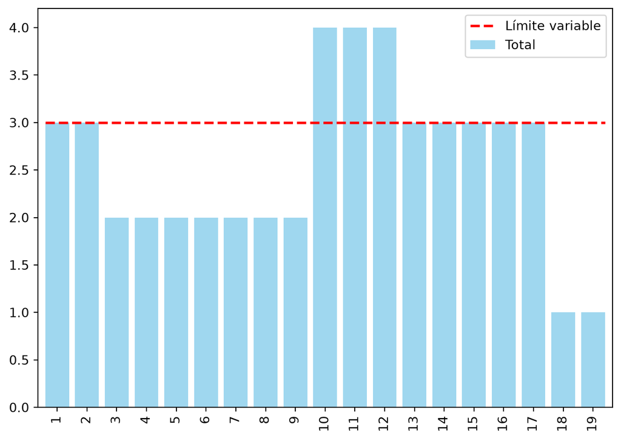

Figura 3: Carga de operarios frente al límite

Camino crítico (la ruta de mayor duración; sus actividades tienen holgura total nula):

- **B – E – G – H**: 5 + 4 + 8 + 2 = **19** semanas

**Duración del proyecto: 19 semanas.**

Sin límite el proyecto dura 19 semanas, pero con los inicios más tempranos se superan los 3 operarios disponibles (semana 10: F(1) + G(3) = 4; semana 11: F(1) + G(3) = 4; semana 12: F(1) + G(3) = 4 operarios): hay que reprogramar.

El algoritmo de asignación recorre las semanas una a una. En cada semana son *candidatas* las actividades no empezadas cuyas predecesoras han terminado; se ordenan por prioridad (menor inicio más tardío en el calendario sin recursos, después menor duración) y cada una empieza si, en todas las semanas que ocuparía, los operarios ya comprometidos más los suyos no superan el límite; si no, espera. La traza muestra la decisión de cada semana y, entre paréntesis, el recurso que bloquea a las que esperan.

Periodo 1. Empiezan: [‘B’, ‘A’]. Esperan: []

Periodo 3. Empiezan: [‘C’]. Esperan: []

Periodo 4. Empiezan: [‘D’]. Esperan: []

Periodo 6. Empiezan: [‘E’]. Esperan: []

Periodo 9. Empiezan: [‘F’]. Esperan: []

Periodo 10. Empiezan: []. Esperan: [‘G (operarios)’]

Periodo 11. Empiezan: []. Esperan: [‘G (operarios)’]

Periodo 12. Empiezan: []. Esperan: [‘G (operarios)’]

Periodo 13. Empiezan: [‘G’]. Esperan: []

Periodo 21. Empiezan: [‘H’]. Esperan: []

[figure not shown]

Figura 4: Gantt con el límite de operarios (filas 💤: esperas por falta de operarios)

Tabla 3: Calendario con recursos: inicio, fin y espera de cada actividad

|  | inicio sin límite | inicio con límite | fin con límite | espera (semanas) |
| --- | --- | --- | --- | --- |
| A | 0 | 0 | 2 | 0 |
| B | 0 | 0 | 5 | 0 |
| C | 2 | 2 | 3 | 0 |
| D | 3 | 3 | 8 | 0 |
| E | 5 | 5 | 9 | 0 |
| F | 8 | 8 | 12 | 0 |
| G | 9 | 12 | 20 | 3 |
| H | 17 | 20 | 22 | 0 |

Tabla 4: Carga de operarios semana a semana frente al límite

| periodo | 1 | 2 | 3 | 4 | 5 | 6 | 7 | 8 | 9 | 10 | 11 | 12 | 13 | 14 | 15 | 16 | 17 | 18 | 19 | 20 | 21 | 22 |
| --- | --- | --- | --- | --- | --- | --- | --- | --- | --- | --- | --- | --- | --- | --- | --- | --- | --- | --- | --- | --- | --- | --- |
| operarios ocupados | 3.0 | 3.0 | 2.0 | 2.0 | 2.0 | 2.0 | 2.0 | 2.0 | 2.0 | 1.0 | 1.0 | 1.0 | 3.0 | 3.0 | 3.0 | 3.0 | 3.0 | 3.0 | 3.0 | 3.0 | 1.0 | 1.0 |
| límite | 3.0 | 3.0 | 3.0 | 3.0 | 3.0 | 3.0 | 3.0 | 3.0 | 3.0 | 3.0 | 3.0 | 3.0 | 3.0 | 3.0 | 3.0 | 3.0 | 3.0 | 3.0 | 3.0 | 3.0 | 3.0 | 3.0 |

Sin límite: 19 semanas. Con 3 operarios: 22 semanas (3 más). Actividades de la cadena crítica con recursos: A, C, D, F, G y H; sus arcos:

Tabla 5: Arcos de la cadena crítica con recursos

|  | de | a | motivo (precedencia o recurso) |
| --- | --- | --- | --- |
| 0 | A | C | precedencia |
| 1 | C | D | precedencia |
| 2 | D | F | precedencia |
| 3 | F | G | recurso |
| 4 | G | H | precedencia |

La cadena crítica con recursos se lee hacia atrás desde la última actividad: cada arco une una actividad con otra que empieza justo cuando ella termina, bien porque es su predecesora (*precedencia*), bien porque le libera los operarios que esperaba (*recurso*). Los arcos de recurso son esperas, no prelaciones: la duración la fija esa cadena (precedencias más esperas), no el camino crítico del grafo.

**Respuesta:** sin límite de recursos el proyecto dura 19 semanas; con 3 operarios, 22 semanas (3 semanas más). La cadena crítica con recursos es A (0–2) → C (2–3) → D (3–8) → F (8–12) ⇒ G (12–20) → H (20–22) (→ precedencia, ⇒ espera por recurso). Duración = 2 + 1 + 5 + 4 + 8 + 2 = 22 semanas. Esperas por recurso: G podría empezar en 9 (cuando terminan sus predecesoras), pero espera 3 semanas, hasta 12, a que F libere los operarios.

## Apartado 2

2. Aplique el algoritmo de Ackoff-Sasieni ignorando los recursos para reducir dos semanas, aplique esas reducciones y replanifique con el límite de operarios. ¿Se ha conseguido reducir la duración del proyecto con recursos? ¿Por qué?

Ackoff-Sasieni sólo mira el grafo: acorta en cada paso, una semana, la combinación más barata de actividades que reduce todas las rutas críticas *sin recursos*. La tabla muestra, para cada ruta, el CUR de sus actividades y su duración tras cada paso.

Tabla 6: Algoritmo de Ackoff-Sasieni sin tener en cuenta los recursos

[figure not shown]

paso -1 de 2

[figure not shown]

Algoritmo de Ackoff-Sasieni: tabla completa. Pulse «siguiente» para ver cómo se construye.

Tabla 7: Opciones consideradas en cada paso

| paso | duración | rutas críticas | opciones (coste) | elegida | coste del paso |
| --- | --- | --- | --- | --- | --- |
| 1 | 19 | Route_5 | E (2); B (4); G (9) | E | 2.0 |
| 2 | 18 | Route_5 | E (2); B (4); G (9) | E | 2.0 |

| paso | actividades acortadas | coste del paso |
| --- | --- | --- |
| 1 | E | 2.0 |
| 2 | E | 2.0 |

Aplicadas esas reducciones, se vuelve a programar con el límite de operarios:

Periodo 1. Empiezan: [‘B’, ‘A’]. Esperan: []

Periodo 3. Empiezan: [‘C’]. Esperan: []

Periodo 4. Empiezan: [‘D’]. Esperan: []

Periodo 6. Empiezan: [‘E’]. Esperan: []

Periodo 8. Empiezan: []. Esperan: [‘G (operarios)’]

Periodo 9. Empiezan: [‘G’]. Esperan: [‘F (operarios)’]

Periodo 10. Empiezan: []. Esperan: [‘F (operarios)’]

Periodo 11. Empiezan: []. Esperan: [‘F (operarios)’]

Periodo 12. Empiezan: []. Esperan: [‘F (operarios)’]

Periodo 13. Empiezan: []. Esperan: [‘F (operarios)’]

Periodo 14. Empiezan: []. Esperan: [‘F (operarios)’]

Periodo 15. Empiezan: []. Esperan: [‘F (operarios)’]

Periodo 16. Empiezan: []. Esperan: [‘F (operarios)’]

Periodo 17. Empiezan: [‘F’]. Esperan: []

Periodo 21. Empiezan: [‘H’]. Esperan: []

[figure not shown]

Figura 5: Gantt con el límite de operarios tras las reducciones de Ackoff-Sasieni

Tabla 8: Duración e inicio de cada actividad antes y después de aplicar Ackoff-Sasieni (con el límite)

|  | A | B | C | D | E | F | G | H |
| --- | --- | --- | --- | --- | --- | --- | --- | --- |
| duración normal | 2 | 5 | 1 | 5 | 4 | 4 | 8 | 2 |
| duración Ackoff | 2 | 5 | 1 | 5 | 2 | 4 | 8 | 2 |
| inicio con límite (antes) | 0 | 0 | 2 | 3 | 5 | 8 | 12 | 20 |
| inicio con límite (después) | 0 | 0 | 2 | 3 | 5 | 16 | 8 | 20 |
| fin con límite (antes) | 2 | 5 | 3 | 8 | 9 | 12 | 20 | 22 |
| fin con límite (después) | 2 | 5 | 3 | 8 | 7 | 20 | 16 | 22 |

**Respuesta:** no. Ackoff-Sasieni sin recursos acorta E con un coste de 2 + 2 = 4 k€ y el grafo baja a 17 semanas sobre el papel, pero al replanificar con 3 operarios el proyecto dura 22 semanas (antes 22): E no está en la cadena crítica con recursos del apartado 1, así que acortarla adelanta otras actividades, pero no lo que fija el plazo con recursos. Con las duraciones de Ackoff la cadena que fija el plazo es A (0–2) → C (2–3) → D (3–8) ⇒ G (8–16) ⇒ F (16–20) → H (20–22) (→ precedencia, ⇒ espera por recurso). Duración = 2 + 1 + 5 + 8 + 4 + 2 = 22 semanas. Esperas por recurso: G podría empezar en 7 (cuando terminan sus predecesoras), pero espera 1 semana, hasta 8, a que D libere los operarios; F podría empezar en 8 (cuando terminan sus predecesoras), pero espera 8 semanas, hasta 16, a que G libere los operarios. El dinero se gasta sin acortar lo que de verdad fija el plazo.

## Apartado 3

3. Reduzca ahora dos semanas teniendo en cuenta el límite: pruebe en cada paso los candidatos (cortes de la cadena crítica con recursos, actividades sueltas y parejas) y elija el más barato que de verdad acorte el proyecto replanificado. Compare el sobrecoste con el del apartado anterior.

`crashing_recursos` repite en cada paso cuatro operaciones: (1) programa con el límite, (2) halla la cadena crítica con recursos, (3) evalúa como candidatos las actividades reducibles de esa cadena una a una, por parejas y el corte de coste mínimo de la cadena, **replanificando** con cada candidato, y (4) se queda con el más barato que de verdad acorta la duración replanificada. La tabla muestra, paso a paso, la cadena crítica, lo que habría elegido Ackoff-Sasieni sin recursos, cuántos candidatos se evaluaron y cuántas reducciones de una sola actividad no acortaron nada.

Tabla 9: Crashing con recursos limitados, paso a paso

| paso | cadena crítica con recursos | Ackoff sin recursos elegiría | candidatos evaluados | actividades sueltas que no acortan | se acorta | coste del paso | coste acumulado | duración antes | duración después |
| --- | --- | --- | --- | --- | --- | --- | --- | --- | --- |
| 1 | A, C, D, F, G, H | E | 6 | 0 | A | 2.0 | 2.0 | 22 | 21 |
| 2 | A, C, D, F, G, H | E | 3 | 0 | D | 7.0 | 9.0 | 21 | 20 |

Detalle de cada paso: todos los candidatos evaluados (actividades reducibles de la cadena crítica con recursos, sueltas y por parejas), su coste y la duración que resulta al replanificar con el límite de operarios.

**Paso 1** (duración con recursos 22 semanas). Cadena crítica con recursos: A, C, D, F, G y H; reducibles en ella: A, D y G. Candidatos, de más barato a más caro:

| candidato | coste (k€) | duración replanificada | resultado | elegido |
| --- | --- | --- | --- | --- |
| A | 2 | 21 | acorta a 21 | ✔ |
| D | 7 | 21 | acorta a 21 |  |
| A + D | 2 + 7 = 9 | 20 | acorta a 20 |  |
| G | 9 | 21 | acorta a 21 |  |
| A + G | 2 + 9 = 11 | 20 | acorta a 20 |  |
| D + G | 7 + 9 = 16 | 20 | acorta a 20 |  |

Se elige **A** (2 k€), el candidato más barato que de verdad acorta el proyecto replanificado.

**Paso 2** (duración con recursos 21 semanas). Cadena crítica con recursos: A, C, D, F, G y H; reducibles en ella: D y G. Candidatos, de más barato a más caro:

| candidato | coste (k€) | duración replanificada | resultado | elegido |
| --- | --- | --- | --- | --- |
| D | 7 | 20 | acorta a 20 | ✔ |
| G | 9 | 20 | acorta a 20 |  |
| D + G | 7 + 9 = 16 | 19 | acorta a 19 |  |

Se elige **D** (7 k€), el candidato más barato que de verdad acorta el proyecto replanificado.

Tabla 10: Duraciones finales y semanas recortadas a cada actividad

| activity | A | B | C | D | E | F | G | H |
| --- | --- | --- | --- | --- | --- | --- | --- | --- |
| duración normal | 2.0 | 5.0 | 1.0 | 5.0 | 4.0 | 4.0 | 8.0 | 2.0 |
| duración tope | 1.0 | 2.0 | 1.0 | 2.0 | 2.0 | 4.0 | 5.0 | 2.0 |
| duración final | 1.0 | 5.0 | 1.0 | 4.0 | 4.0 | 4.0 | 8.0 | 2.0 |
| recortado | 1.0 | 0.0 | 0.0 | 1.0 | 0.0 | 0.0 | 0.0 | 0.0 |
| CUR | 2.0 | 4.0 | inf | 7.0 | 2.0 | inf | 9.0 | inf |

[figure not shown]

Figura 6: Gantt con el límite de operarios tras el crashing con recursos

**Respuesta:** se acortan A 1 semana y D 1 semana: la duración con recursos pasa de 22 a 20 semanas (se consigue la reducción pedida) con un sobrecoste de 2 + 7 = **9 k€**, frente a los 4 k€ de Ackoff sin recursos, que no acortaban nada (el proyecto quedaba en 22). Cuesta más, pero es dinero que sí acorta el proyecto: se acortan actividades de la cadena crítica con recursos y se comprueba en cada paso, replanificando, que el proyecto termina antes.

## Apartado 4

4. Suponga que acelerar una actividad exige un operario más por cada semana recortada (modelo con recurso). ¿Cambia la solución?

En el modelo *con recurso*, acelerar una actividad consume operarios: cada semana recortada añade un operario a su demanda, de modo que la reducción puede chocar con el mismo límite que intenta esquivar.

Tabla 11: Crashing con recursos cuando acelerar consume un operario por semana recortada

| paso | cadena crítica con recursos | candidatos evaluados | se acorta | coste del paso | coste acumulado | duración antes | duración después |
| --- | --- | --- | --- | --- | --- | --- | --- |
| 1 | A, C, D, F, G, H | 3 | D | 7.0 | 7.0 | 22 | 21 |

**Paso 1** (duración con recursos 22 semanas). Cadena crítica con recursos: A, C, D, F, G y H; reducibles en ella: A, D y G. Candidatos, de más barato a más caro:

| candidato | coste (k€) | duración replanificada | resultado | elegido |
| --- | --- | --- | --- | --- |
| A | 2 | 26 | no acorta |  |
| D | 7 | 21 | acorta a 21 | ✔ |
| A + D | 2 + 7 = 9 | 25 | no acorta |  |
| G | 9 | — | necesita más de 3 operarios: no cabe |  |
| A + G | 2 + 9 = 11 | — | necesita más de 3 operarios: no cabe |  |
| D + G | 7 + 9 = 16 | — | necesita más de 3 operarios: no cabe |  |

Se elige **D** (7 k€), el candidato más barato que de verdad acorta el proyecto replanificado; los más baratos (A) no lo acortan o no caben en el límite.

Tabla 12: Demanda de operarios de cada actividad tras las reducciones (modelo con recurso)

| activity | A | B | C | D | E | F | G | H |
| --- | --- | --- | --- | --- | --- | --- | --- | --- |
| operarios (normal) | 2.0 | 1.0 | 1.0 | 1.0 | 1.0 | 1.0 | 3.0 | 1.0 |
| operarios (tras recortar) | 2.0 | 1.0 | 1.0 | 2.0 | 1.0 | 1.0 | 3.0 | 1.0 |
| recortado | 0.0 | 0.0 | 0.0 | 1.0 | 0.0 | 0.0 | 0.0 | 0.0 |

**Respuesta:** sí cambia: acortando D 1 semana solo se llega a 21 semanas, 1 semana de las 2 pedidas, con 7 k€; después ninguna reducción de una semana acorta el proyecto, porque el operario extra que exige acelerar no cabe en el límite o retrasa a otra actividad. Sin ampliar el recurso no se alcanza lo pedido.

## Apartado 5

5. Alternativa: contratar un operario más (límite 4) sin acelerar nada. ¿Qué duración se obtiene? ¿Compensa frente a acelerar?

Periodo 1. Empiezan: [‘B’, ‘A’]. Esperan: []

Periodo 3. Empiezan: [‘C’]. Esperan: []

Periodo 4. Empiezan: [‘D’]. Esperan: []

Periodo 6. Empiezan: [‘E’]. Esperan: []

Periodo 9. Empiezan: [‘F’]. Esperan: []

Periodo 10. Empiezan: [‘G’]. Esperan: []

Periodo 18. Empiezan: [‘H’]. Esperan: []

[figure not shown]

Figura 7: Gantt con un operario más, sin acelerar ninguna actividad

**Respuesta:** con 4 operarios y sin acelerar nada el proyecto dura 19 semanas (antes 22): ahorra 3 semanas y ya cumple el objetivo de 20 semanas. Acelerar con 3 operarios cuesta 9 k€, así que compensa contratar si el operario adicional cuesta menos de 9 k€ en las 19 semanas del proyecto, es decir, menos de 9/19 = 0.47 k€ por semana.